# Online News Popularity

Kaggle Competition - Data Science 2 Course

Kata Süle

10th April 2021

```r
library(tidyverse)
library(skimr)
library(h2o)
library(kableExtra)
library(GGally)
h2o.init()
```

```
##  Connection successful!
##
## R is connected to the H2O cluster:
##     H2O cluster uptime:         22 days 1 hours
##     H2O cluster timezone:       Europe/Amsterdam
##     H2O data parsing timezone:  UTC
##     H2O cluster version:        3.32.0.4
##     H2O cluster version age:    2 months and 9 days
##     H2O cluster name:           H2O_started_from_R_JAS_ufx523
##     H2O cluster total nodes:    1
##     H2O cluster total memory:   0.35 GB
##     H2O cluster total cores:    4
##     H2O cluster allowed cores:  4
##     H2O cluster healthy:        TRUE
##     H2O Connection ip:          localhost
##     H2O Connection port:        54321
##     H2O Connection proxy:       NA
##     H2O Internal Security:      FALSE
##     H2O API Extensions:         Amazon S3, XGBoost, Algos, AutoML, Core V3, TargetEncoder, Core V4
##     R Version:                  R version 4.0.4 (2021-02-15)
```

```r
theme_set(theme_light())
my_seed <- 20210409
```

## Executive summary

The aim of this report was to build predictive models which can be used to predict whether a certain article on a website is going to be among the most popular ones. By using 44 features and training 6 different types of models: lasso, random forest, gradient boosting, xgboost, neural network and a stacked ensemble I managed to reach an AUC of 0.7 for the validation set.

## 1. Import and clean data

The dataset contains information about articles which were published on [mashable.com](https://mashable.com/). The train set contains 27752, while the test set has 11892 observations. There are 60 features in total which show different characteristics of the articles such as the number of words they have or their sentiment. The aim was to predict whether an article is going to end up among the most popular articles on mashable.com based on the given features.

```r
# import data
train <- read_csv("/Users/JAS/Documents/Kata/Kaggle competition/data/train.csv")
test <- read_csv("/Users/JAS/Documents/Kata/Kaggle competition/data/test.csv")
```

After importing the data I checked whether the variable types were all correct. All variables were stored in a numeric format even though some of them were binary. I decided to convert the binary variables to two level factor variables. This included the outcome variable `is_popular` as well.

```r
# check variable types
#str(train)
#str(test)

# convert binary variables to factor for train
train <- train %>% mutate(
  data_channel_is_lifestyle = factor(data_channel_is_lifestyle),
  data_channel_is_entertainment = factor(data_channel_is_entertainment),
  data_channel_is_bus = factor(data_channel_is_bus),
  data_channel_is_socmed = factor(data_channel_is_socmed),
  data_channel_is_tech = factor(data_channel_is_tech),
  data_channel_is_world = factor(data_channel_is_world),
  weekday_is_monday = factor(weekday_is_monday),
  weekday_is_tuesday = factor(weekday_is_tuesday),
  weekday_is_wednesday = factor(weekday_is_wednesday),
  weekday_is_thursday = factor(weekday_is_thursday),
  weekday_is_friday = factor(weekday_is_friday),
  weekday_is_saturday = factor(weekday_is_saturday),
  weekday_is_sunday = factor(weekday_is_sunday),
  is_weekend = factor(is_weekend),
  article_id = factor(article_id),
)

# convert binary variables to factor for test
test <- test %>% mutate(
  data_channel_is_lifestyle = factor(data_channel_is_lifestyle),
  data_channel_is_entertainment = factor(data_channel_is_entertainment),
  data_channel_is_bus = factor(data_channel_is_bus),
  data_channel_is_socmed = factor(data_channel_is_socmed),
  data_channel_is_tech = factor(data_channel_is_tech),
  data_channel_is_world = factor(data_channel_is_world),
  weekday_is_monday = factor(weekday_is_monday),
  weekday_is_tuesday = factor(weekday_is_tuesday),
  weekday_is_wednesday = factor(weekday_is_wednesday),
  weekday_is_thursday = factor(weekday_is_thursday),
  weekday_is_friday = factor(weekday_is_friday),
  weekday_is_saturday = factor(weekday_is_saturday),
  weekday_is_sunday = factor(weekday_is_sunday),
  is_weekend = factor(is_weekend),
  article_id = factor(article_id)
)

# convert outcome variable to a 2 level factor
train <- train %>%
  mutate(is_popular = factor(is_popular, levels = c(0,1)) %>%
           recode(., `0` = 'no', `1` = "yes"))
```

Then I checked the number of missing values and I found that all observations were complete.

```r
# skim data
skim(train)
```

Data summary

| Name | train |
| --- | --- |
| Number of rows | 27752 |
| Number of columns | 60 |
| _______________________ |  |
| Column type frequency: |  |
| factor | 16 |
| numeric | 44 |
| ________________________ |  |
| Group variables | None |

**Variable type: factor**

| skim_variable | n_missing | complete_rate | ordered | n_unique | top_counts |
| --- | --- | --- | --- | --- | --- |
| data_channel_is_lifestyle | 0 | 1 | FALSE | 2 | 0: 26258, 1: 1494 |
| data_channel_is_entertainment | 0 | 1 | FALSE | 2 | 0: 22833, 1: 4919 |
| data_channel_is_bus | 0 | 1 | FALSE | 2 | 0: 23375, 1: 4377 |
| data_channel_is_socmed | 0 | 1 | FALSE | 2 | 0: 26133, 1: 1619 |
| data_channel_is_tech | 0 | 1 | FALSE | 2 | 0: 22549, 1: 5203 |
| data_channel_is_world | 0 | 1 | FALSE | 2 | 0: 21899, 1: 5853 |
| weekday_is_monday | 0 | 1 | FALSE | 2 | 0: 23088, 1: 4664 |
| weekday_is_tuesday | 0 | 1 | FALSE | 2 | 0: 22589, 1: 5163 |
| weekday_is_wednesday | 0 | 1 | FALSE | 2 | 0: 22544, 1: 5208 |
| weekday_is_thursday | 0 | 1 | FALSE | 2 | 0: 22621, 1: 5131 |
| weekday_is_friday | 0 | 1 | FALSE | 2 | 0: 23804, 1: 3948 |
| weekday_is_saturday | 0 | 1 | FALSE | 2 | 0: 26031, 1: 1721 |
| weekday_is_sunday | 0 | 1 | FALSE | 2 | 0: 25835, 1: 1917 |
| is_weekend | 0 | 1 | FALSE | 2 | 0: 24114, 1: 3638 |
| is_popular | 0 | 1 | FALSE | 2 | no: 22286, yes: 5466 |
| article_id | 0 | 1 | FALSE | 27752 | 2: 1, 3: 1, 5: 1, 6: 1 |

**Variable type: numeric**

| skim_variable | n_missing | complete_rate | mean | sd | p0 | p25 | p50 | p75 | p100 | hist |
| --- | --- | --- | --- | --- | --- | --- | --- | --- | --- | --- |
| n_tokens_title | 0 | 1 | 10.38 | 2.11 | 3.00 | 9.00 | 10.00 | 12.00 | 20.00 | ▁▅▇▁▁ |
| n_tokens_content | 0 | 1 | 546.56 | 471.66 | 0.00 | 246.00 | 409.00 | 717.00 | 7764.00 | ▇▁▁▁▁ |
| n_unique_tokens | 0 | 1 | 0.56 | 4.21 | 0.00 | 0.47 | 0.54 | 0.61 | 701.00 | ▇▁▁▁▁ |
| n_non_stop_words | 0 | 1 | 1.01 | 6.25 | 0.00 | 1.00 | 1.00 | 1.00 | 1042.00 | ▇▁▁▁▁ |
| n_non_stop_unique_tokens | 0 | 1 | 0.70 | 3.90 | 0.00 | 0.63 | 0.69 | 0.75 | 650.00 | ▇▁▁▁▁ |
| num_hrefs | 0 | 1 | 10.92 | 11.40 | 0.00 | 4.00 | 8.00 | 14.00 | 304.00 | ▇▁▁▁▁ |
| num_self_hrefs | 0 | 1 | 3.30 | 3.85 | 0.00 | 1.00 | 3.00 | 4.00 | 116.00 | ▇▁▁▁▁ |
| num_imgs | 0 | 1 | 4.61 | 8.36 | 0.00 | 1.00 | 1.00 | 4.00 | 111.00 | ▇▁▁▁▁ |
| num_videos | 0 | 1 | 1.23 | 4.07 | 0.00 | 0.00 | 0.00 | 1.00 | 91.00 | ▇▁▁▁▁ |
| average_token_length | 0 | 1 | 4.55 | 0.84 | 0.00 | 4.48 | 4.66 | 4.86 | 8.04 | ▁▁▇▃▁ |
| num_keywords | 0 | 1 | 7.23 | 1.91 | 1.00 | 6.00 | 7.00 | 9.00 | 10.00 | ▁▂▇▇▇ |
| kw_min_min | 0 | 1 | 26.26 | 69.82 | -1.00 | -1.00 | -1.00 | 4.00 | 377.00 | ▇▁▁▁▁ |
| kw_max_min | 0 | 1 | 1165.99 | 4147.64 | 0.00 | 448.00 | 662.00 | 1000.00 | 298400.00 | ▇▁▁▁▁ |
| kw_avg_min | 0 | 1 | 314.70 | 670.78 | -1.00 | 142.50 | 235.94 | 358.22 | 42827.86 | ▇▁▁▁▁ |
| kw_min_max | 0 | 1 | 13529.57 | 57297.42 | 0.00 | 0.00 | 1400.00 | 7900.00 | 843300.00 | ▇▁▁▁▁ |
| kw_max_max | 0 | 1 | 751996.26 | 214875.42 | 0.00 | 843300.00 | 843300.00 | 843300.00 | 843300.00 | ▁▁▁▁▇ |
| kw_avg_max | 0 | 1 | 258825.28 | 134555.01 | 0.00 | 172477.50 | 244297.86 | 330700.00 | 843300.00 | ▃▇▃▁▁ |
| kw_min_avg | 0 | 1 | 1118.68 | 1138.40 | -1.00 | 0.00 | 1024.77 | 2060.03 | 3613.04 | ▇▃▃▂▂ |
| kw_max_avg | 0 | 1 | 5676.57 | 6346.89 | 0.00 | 3566.30 | 4359.61 | 6018.30 | 298400.00 | ▇▁▁▁▁ |
| kw_avg_avg | 0 | 1 | 3140.74 | 1343.01 | 0.00 | 2387.63 | 2870.55 | 3608.71 | 43567.66 | ▇▁▁▁▁ |
| self_reference_min_shares | 0 | 1 | 4123.98 | 20926.43 | 0.00 | 638.00 | 1200.00 | 2700.00 | 843300.00 | ▇▁▁▁▁ |
| self_reference_max_shares | 0 | 1 | 10401.31 | 41383.32 | 0.00 | 1100.00 | 2800.00 | 7900.00 | 843300.00 | ▇▁▁▁▁ |
| self_reference_avg_sharess | 0 | 1 | 6479.49 | 24979.25 | 0.00 | 978.79 | 2200.00 | 5199.40 | 843300.00 | ▇▁▁▁▁ |
| LDA_00 | 0 | 1 | 0.18 | 0.26 | 0.00 | 0.03 | 0.03 | 0.24 | 0.92 | ▇▁▁▁▁ |
| LDA_01 | 0 | 1 | 0.14 | 0.22 | 0.00 | 0.03 | 0.03 | 0.15 | 0.93 | ▇▁▁▁▁ |
| LDA_02 | 0 | 1 | 0.21 | 0.28 | 0.00 | 0.03 | 0.04 | 0.33 | 0.92 | ▇▁▁▁▁ |
| LDA_03 | 0 | 1 | 0.22 | 0.30 | 0.00 | 0.03 | 0.04 | 0.38 | 0.93 | ▇▁▁▁▂ |
| LDA_04 | 0 | 1 | 0.24 | 0.29 | 0.00 | 0.03 | 0.04 | 0.40 | 0.93 | ▇▂▁▁▂ |
| global_subjectivity | 0 | 1 | 0.44 | 0.12 | 0.00 | 0.40 | 0.45 | 0.51 | 1.00 | ▁▃▇▁▁ |
| global_sentiment_polarity | 0 | 1 | 0.12 | 0.10 | -0.39 | 0.06 | 0.12 | 0.18 | 0.73 | ▁▂▇▁▁ |
| global_rate_positive_words | 0 | 1 | 0.04 | 0.02 | 0.00 | 0.03 | 0.04 | 0.05 | 0.16 | ▅▇▁▁▁ |
| global_rate_negative_words | 0 | 1 | 0.02 | 0.01 | 0.00 | 0.01 | 0.02 | 0.02 | 0.18 | ▇▁▁▁▁ |
| rate_positive_words | 0 | 1 | 0.68 | 0.19 | 0.00 | 0.60 | 0.71 | 0.80 | 1.00 | ▁▁▃▇▃ |
| rate_negative_words | 0 | 1 | 0.29 | 0.16 | 0.00 | 0.19 | 0.28 | 0.38 | 1.00 | ▅▇▃▁▁ |
| avg_positive_polarity | 0 | 1 | 0.35 | 0.10 | 0.00 | 0.31 | 0.36 | 0.41 | 1.00 | ▁▇▃▁▁ |
| min_positive_polarity | 0 | 1 | 0.10 | 0.07 | 0.00 | 0.05 | 0.10 | 0.10 | 1.00 | ▇▁▁▁▁ |
| max_positive_polarity | 0 | 1 | 0.76 | 0.25 | 0.00 | 0.60 | 0.80 | 1.00 | 1.00 | ▁▁▅▅▇ |
| avg_negative_polarity | 0 | 1 | -0.26 | 0.13 | -1.00 | -0.33 | -0.25 | -0.19 | 0.00 | ▁▁▂▇▃ |
| min_negative_polarity | 0 | 1 | -0.52 | 0.29 | -1.00 | -0.70 | -0.50 | -0.30 | 0.00 | ▆▆▇▅▅ |
| max_negative_polarity | 0 | 1 | -0.11 | 0.10 | -1.00 | -0.12 | -0.10 | -0.05 | 0.00 | ▁▁▁▁▇ |
| title_subjectivity | 0 | 1 | 0.28 | 0.32 | 0.00 | 0.00 | 0.15 | 0.50 | 1.00 | ▇▂▂▁▂ |
| title_sentiment_polarity | 0 | 1 | 0.07 | 0.27 | -1.00 | 0.00 | 0.00 | 0.15 | 1.00 | ▁▁▇▂▁ |
| abs_title_subjectivity | 0 | 1 | 0.34 | 0.19 | 0.00 | 0.17 | 0.50 | 0.50 | 0.50 | ▃▂▁▁▇ |
| abs_title_sentiment_polarity | 0 | 1 | 0.16 | 0.23 | 0.00 | 0.00 | 0.00 | 0.25 | 1.00 | ▇▂▁▁▁ |

```r
skim(test)
```

Data summary

| Name | test |
| --- | --- |
| Number of rows | 11892 |
| Number of columns | 59 |
| _______________________ |  |
| Column type frequency: |  |
| factor | 15 |
| numeric | 44 |
| ________________________ |  |
| Group variables | None |

**Variable type: factor**

| skim_variable | n_missing | complete_rate | ordered | n_unique | top_counts |
| --- | --- | --- | --- | --- | --- |
| data_channel_is_lifestyle | 0 | 1 | FALSE | 2 | 0: 11287, 1: 605 |
| data_channel_is_entertainment | 0 | 1 | FALSE | 2 | 0: 9754, 1: 2138 |
| data_channel_is_bus | 0 | 1 | FALSE | 2 | 0: 10011, 1: 1881 |
| data_channel_is_socmed | 0 | 1 | FALSE | 2 | 0: 11188, 1: 704 |
| data_channel_is_tech | 0 | 1 | FALSE | 2 | 0: 9749, 1: 2143 |
| data_channel_is_world | 0 | 1 | FALSE | 2 | 0: 9318, 1: 2574 |
| weekday_is_monday | 0 | 1 | FALSE | 2 | 0: 9895, 1: 1997 |
| weekday_is_tuesday | 0 | 1 | FALSE | 2 | 0: 9665, 1: 2227 |
| weekday_is_wednesday | 0 | 1 | FALSE | 2 | 0: 9665, 1: 2227 |
| weekday_is_thursday | 0 | 1 | FALSE | 2 | 0: 9756, 1: 2136 |
| weekday_is_friday | 0 | 1 | FALSE | 2 | 0: 10139, 1: 1753 |
| weekday_is_saturday | 0 | 1 | FALSE | 2 | 0: 11160, 1: 732 |
| weekday_is_sunday | 0 | 1 | FALSE | 2 | 0: 11072, 1: 820 |
| is_weekend | 0 | 1 | FALSE | 2 | 0: 10340, 1: 1552 |
| article_id | 0 | 1 | FALSE | 11892 | 1: 1, 4: 1, 7: 1, 8: 1 |

**Variable type: numeric**

| skim_variable | n_missing | complete_rate | mean | sd | p0 | p25 | p50 | p75 | p100 | hist |
| --- | --- | --- | --- | --- | --- | --- | --- | --- | --- | --- |
| n_tokens_title | 0 | 1 | 10.44 | 2.13 | 2.00 | 9.00 | 10.00 | 12.00 | 23.00 | ▁▇▇▁▁ |
| n_tokens_content | 0 | 1 | 546.42 | 469.83 | 0.00 | 246.00 | 410.00 | 713.00 | 8474.00 | ▇▁▁▁▁ |
| n_unique_tokens | 0 | 1 | 0.53 | 0.14 | 0.00 | 0.47 | 0.54 | 0.61 | 1.00 | ▁▁▇▃▁ |
| n_non_stop_words | 0 | 1 | 0.97 | 0.17 | 0.00 | 1.00 | 1.00 | 1.00 | 1.00 | ▁▁▁▁▇ |
| n_non_stop_unique_tokens | 0 | 1 | 0.67 | 0.16 | 0.00 | 0.63 | 0.69 | 0.75 | 1.00 | ▁▁▂▇▂ |
| num_hrefs | 0 | 1 | 10.81 | 11.17 | 0.00 | 4.00 | 7.00 | 14.00 | 187.00 | ▇▁▁▁▁ |
| num_self_hrefs | 0 | 1 | 3.27 | 3.86 | 0.00 | 1.00 | 2.00 | 4.00 | 74.00 | ▇▁▁▁▁ |
| num_imgs | 0 | 1 | 4.40 | 8.20 | 0.00 | 1.00 | 1.00 | 4.00 | 128.00 | ▇▁▁▁▁ |
| num_videos | 0 | 1 | 1.29 | 4.19 | 0.00 | 0.00 | 0.00 | 1.00 | 75.00 | ▇▁▁▁▁ |
| average_token_length | 0 | 1 | 4.55 | 0.85 | 0.00 | 4.48 | 4.67 | 4.85 | 6.82 | ▁▁▁▇▁ |
| num_keywords | 0 | 1 | 7.20 | 1.92 | 1.00 | 6.00 | 7.00 | 9.00 | 10.00 | ▁▂▇▇▇ |
| kw_min_min | 0 | 1 | 25.74 | 69.20 | -1.00 | -1.00 | -1.00 | 4.00 | 294.00 | ▇▁▁▁▁ |
| kw_max_min | 0 | 1 | 1125.85 | 3077.76 | 0.00 | 444.00 | 656.00 | 1000.00 | 111300.00 | ▇▁▁▁▁ |
| kw_avg_min | 0 | 1 | 306.92 | 484.43 | -1.00 | 139.50 | 234.33 | 354.49 | 18687.83 | ▇▁▁▁▁ |
| kw_min_max | 0 | 1 | 13805.55 | 59564.05 | 0.00 | 0.00 | 1400.00 | 7800.00 | 843300.00 | ▇▁▁▁▁ |
| kw_max_max | 0 | 1 | 753089.05 | 213635.51 | 0.00 | 843300.00 | 843300.00 | 843300.00 | 843300.00 | ▁▁▁▁▇ |
| kw_avg_max | 0 | 1 | 260347.62 | 136370.52 | 0.00 | 173446.43 | 245225.00 | 331533.33 | 843300.00 | ▃▇▃▁▁ |
| kw_min_avg | 0 | 1 | 1113.57 | 1135.30 | -1.00 | 0.00 | 1022.25 | 2050.04 | 3610.12 | ▇▃▃▂▂ |
| kw_max_avg | 0 | 1 | 5612.03 | 5476.55 | 0.00 | 3557.85 | 4347.76 | 6028.37 | 171030.25 | ▇▁▁▁▁ |
| kw_avg_avg | 0 | 1 | 3124.47 | 1258.22 | 0.00 | 2370.09 | 2868.20 | 3581.63 | 37607.52 | ▇▁▁▁▁ |
| self_reference_min_shares | 0 | 1 | 3706.53 | 16637.42 | 0.00 | 641.00 | 1200.00 | 2600.00 | 690400.00 | ▇▁▁▁▁ |
| self_reference_max_shares | 0 | 1 | 10160.95 | 40186.35 | 0.00 | 1100.00 | 2900.00 | 8000.00 | 843300.00 | ▇▁▁▁▁ |
| self_reference_avg_sharess | 0 | 1 | 6220.16 | 22316.67 | 0.00 | 988.75 | 2200.00 | 5200.00 | 690400.00 | ▇▁▁▁▁ |
| LDA_00 | 0 | 1 | 0.19 | 0.26 | 0.02 | 0.03 | 0.03 | 0.24 | 0.93 | ▇▁▁▁▁ |
| LDA_01 | 0 | 1 | 0.14 | 0.22 | 0.02 | 0.03 | 0.03 | 0.15 | 0.92 | ▇▁▁▁▁ |
| LDA_02 | 0 | 1 | 0.22 | 0.28 | 0.02 | 0.03 | 0.04 | 0.34 | 0.92 | ▇▁▁▁▁ |
| LDA_03 | 0 | 1 | 0.22 | 0.29 | 0.02 | 0.03 | 0.04 | 0.37 | 0.93 | ▇▁▁▁▁ |
| LDA_04 | 0 | 1 | 0.23 | 0.29 | 0.02 | 0.03 | 0.04 | 0.39 | 0.93 | ▇▁▁▁▁ |
| global_subjectivity | 0 | 1 | 0.44 | 0.12 | 0.00 | 0.40 | 0.45 | 0.51 | 1.00 | ▁▃▇▁▁ |
| global_sentiment_polarity | 0 | 1 | 0.12 | 0.10 | -0.38 | 0.06 | 0.12 | 0.18 | 0.66 | ▁▂▇▁▁ |
| global_rate_positive_words | 0 | 1 | 0.04 | 0.02 | 0.00 | 0.03 | 0.04 | 0.05 | 0.14 | ▃▇▂▁▁ |
| global_rate_negative_words | 0 | 1 | 0.02 | 0.01 | 0.00 | 0.01 | 0.02 | 0.02 | 0.10 | ▇▃▁▁▁ |
| rate_positive_words | 0 | 1 | 0.68 | 0.19 | 0.00 | 0.60 | 0.71 | 0.80 | 1.00 | ▁▁▃▇▃ |
| rate_negative_words | 0 | 1 | 0.29 | 0.16 | 0.00 | 0.19 | 0.28 | 0.38 | 1.00 | ▅▇▃▁▁ |
| avg_positive_polarity | 0 | 1 | 0.35 | 0.11 | 0.00 | 0.31 | 0.36 | 0.41 | 1.00 | ▁▇▃▁▁ |
| min_positive_polarity | 0 | 1 | 0.10 | 0.07 | 0.00 | 0.05 | 0.10 | 0.10 | 1.00 | ▇▁▁▁▁ |
| max_positive_polarity | 0 | 1 | 0.76 | 0.25 | 0.00 | 0.60 | 0.80 | 1.00 | 1.00 | ▁▁▅▅▇ |
| avg_negative_polarity | 0 | 1 | -0.26 | 0.13 | -1.00 | -0.33 | -0.25 | -0.19 | 0.00 | ▁▁▂▇▃ |
| min_negative_polarity | 0 | 1 | -0.52 | 0.29 | -1.00 | -0.70 | -0.50 | -0.30 | 0.00 | ▇▆▇▅▅ |
| max_negative_polarity | 0 | 1 | -0.11 | 0.09 | -1.00 | -0.12 | -0.10 | -0.05 | 0.00 | ▁▁▁▁▇ |
| title_subjectivity | 0 | 1 | 0.28 | 0.32 | 0.00 | 0.00 | 0.14 | 0.50 | 1.00 | ▇▂▂▁▂ |
| title_sentiment_polarity | 0 | 1 | 0.07 | 0.26 | -1.00 | 0.00 | 0.00 | 0.14 | 1.00 | ▁▁▇▂▁ |
| abs_title_subjectivity | 0 | 1 | 0.34 | 0.19 | 0.00 | 0.17 | 0.50 | 0.50 | 0.50 | ▃▂▁▁▇ |
| abs_title_sentiment_polarity | 0 | 1 | 0.16 | 0.22 | 0.00 | 0.00 | 0.00 | 0.25 | 1.00 | ▇▂▁▁▁ |

## 2. Feature engineering

As for feature engineering I read through the variable descriptions to see which features might be redundant. Furthermore, to backup my decisions I inspected correlation between certain groups of variables.

The plot below shows the correlation between polarity measures. Based on it I decided to exclude those ones which contain averages because they were highly correlated with the other features.

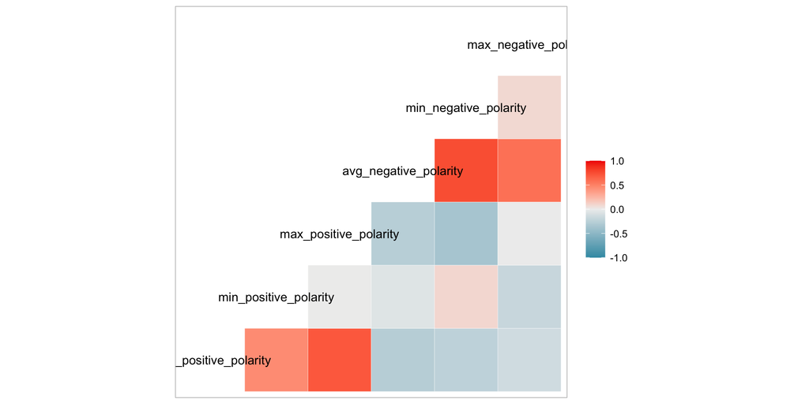

```r
# check correlations between polarity measures
ggcorr(subset(train,select = c(avg_positive_polarity,min_positive_polarity,max_positive_polarity, avg_negative_polarity,min_negative_polarity,max_negative_polarity)))
```

I also checked the correlation between the measures about keyword shares. Based on the plot below I decided to drop all those which contained averages.

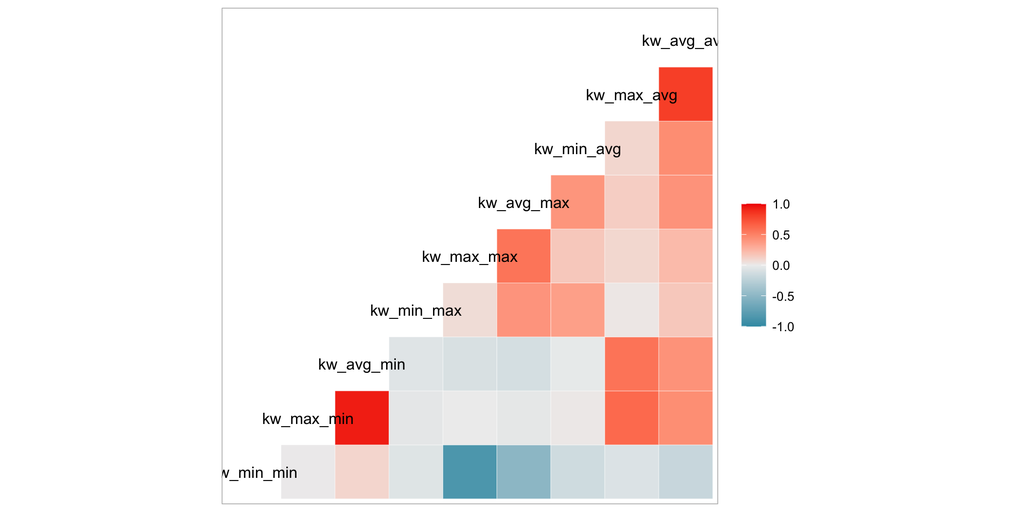

```r
# check correlations between keyword measures
ggcorr(subset(train,select = c(kw_min_min, kw_max_min, kw_avg_min, kw_min_max, kw_max_max, kw_avg_max,kw_min_avg,kw_max_avg, kw_avg_avg)))
```

Lastly, I inspected the correlation between variables that contained information about the tokens of the articles. Based on the plot below I decided to exclude the number of unique tokens variable because the number of non-stop unique tokens variable was very close to it.

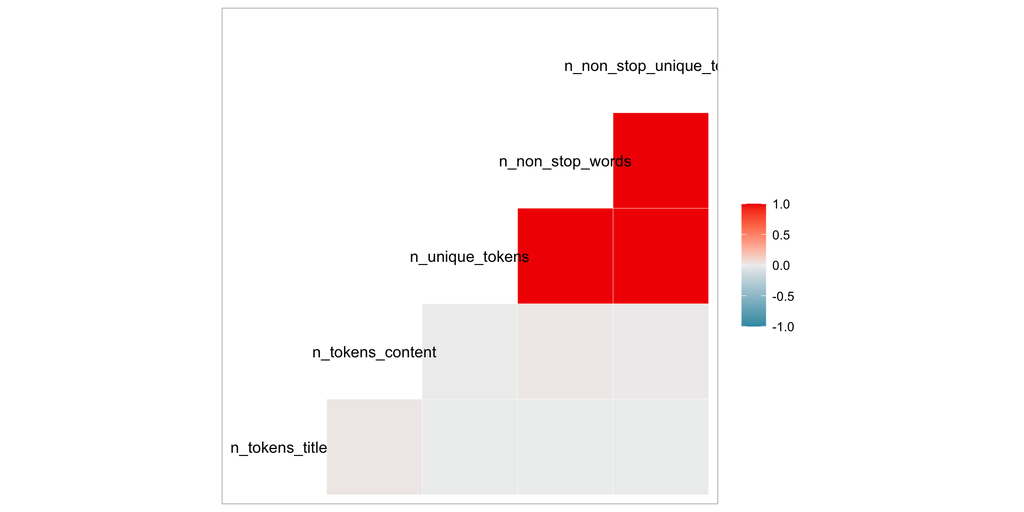

```r
# check correlations between token measures
ggcorr(subset(train,select = c(n_tokens_title, n_tokens_content, n_unique_tokens,n_non_stop_words, n_non_stop_unique_tokens)))
```

I found that the number of non-stop words was very close to 1 for almost all the observations in the train set. This would have meant that the articles barely contained stop words which seemed unnatural. Therefore I decided to exclude it.

```r
# n_non_stop_words is almost always 1 so I exclude it
nrow(train %>% dplyr::filter(n_non_stop_words > 0.99))
```

```
## [1] 26934
```

As for the number of links to other articles on mashable.com I decided to turn it into a ratio instead of a simple number. So I divided it by the number of total references that the articles had. In case they did not have any references I set the value of the ratio to 0.

```r
# add the links to Mashable.com as the percentage of the total links in the article
train <- train %>% mutate(
  perc_self_hrefs = ifelse( num_hrefs == 0, 0, num_self_hrefs / num_hrefs)
  )

test <- test %>% mutate(
  perc_self_hrefs = ifelse( num_hrefs == 0, 0, num_self_hrefs / num_hrefs)
  )
```

```r
# list of variables to drop
# based on either variable understanding or inspection
to_drop <- c("rate_negative_words", "abs_title_subjectivity", "abs_title_sentiment_polarity", "avg_positive_polarity", "avg_negative_polarity", "is_weekend", "self_reference_avg_sharess", "kw_min_avg", "kw_max_avg", "kw_avg_avg", "kw_avg_min", "kw_avg_max","num_self_hrefs", "n_non_stop_words", "n_unique_tokens")

# drop variables
train <- subset(train, select = setdiff(names(train), to_drop))
test <- subset(test, select = setdiff(names(test), to_drop))
```

Then I checked the minimums of the remaining features because some of them were ratios or some kind of measure which cannot be lower than 0.

```r
# check the variables which have lower minimums than 0 because some of them should not be negative
df <- Filter(is.numeric, train)
for (col in names(df)){
  min <- min(df[,col])
  if (min < 0){
   print(c(col, min))
  } else {
    next
  }
}
```

```
## [1] "kw_min_min" "-1"
## [1] "global_sentiment_polarity" "-0.39375"
## [1] "min_negative_polarity" "-1"
## [1] "max_negative_polarity" "-1"
## [1] "title_sentiment_polarity" "-1"
```

Since the `kw_min_min` variable is about number of shares it cannot go below 0. I checked and it was less than 0 for more than 50% of the observations therefore I decided to drop it because I did not want to fill in all those observations with 0.

```r
# number of shares cannot be negative
# it is negative for more than 50% of the observations so I drop this variable
nrow(train %>% dplyr::filter(kw_min_min < 0))
```

```
## [1] 16059
```

```r
train <- subset(train, select = setdiff(names(train), "kw_min_min"))
test <- subset(test, select = setdiff(names(test), "kw_min_min"))
```

As the last step of feature engineering I took logs of variables which had a skewed distribution with a long right tail.

```r
# add logs of skewed features to train
train <- train %>% mutate(
  log_n_tokens_content = ifelse(n_tokens_content == 0, log(n_tokens_content+1), log(n_tokens_content)),
  log_n_non_stop_unique_tokens = ifelse(n_non_stop_unique_tokens == 0, log(n_non_stop_unique_tokens+1), log(n_non_stop_unique_tokens)),
  log_num_hrefs = ifelse(num_hrefs == 0, log(num_hrefs+1), log(num_hrefs)),
  log_num_imgs = ifelse(num_imgs == 0, log(num_imgs+1), log(num_imgs)),
  log_num_videos = ifelse(num_videos == 0, log(num_videos+1), log(num_videos)),
  log_kw_max_min = ifelse(kw_max_min == 0, log(kw_max_min+1), log(kw_max_min)),
  log_kw_min_max = ifelse(kw_min_max == 0, log(kw_min_max+1), log(kw_min_max)),
  log_self_reference_min_shares = ifelse(self_reference_min_shares == 0, log(self_reference_min_shares+1), log(self_reference_min_shares)),
  log_self_reference_max_shares = ifelse(self_reference_max_shares == 0, log(self_reference_max_shares+1), log(self_reference_max_shares)),
  log_LDA_00 = ifelse(LDA_00 == 0, log(LDA_00+ mean(LDA_00)/2), log(LDA_00)),
  log_LDA_01 = ifelse(LDA_01 == 0, log(LDA_01+ mean(LDA_01)/2), log(LDA_01)),
  log_LDA_02 = ifelse(LDA_02 == 0, log(LDA_02+ mean(LDA_02)/2), log(LDA_02)),
  log_LDA_03 = ifelse(LDA_03 == 0, log(LDA_03+ mean(LDA_03)/2), log(LDA_03)),
  log_LDA_04 = ifelse(LDA_04 == 0, log(LDA_04+ mean(LDA_04)/2), log(LDA_04)),
  log_global_rate_negative_words = ifelse(global_rate_negative_words == 0, log(global_rate_negative_words+ mean(global_rate_negative_words)/2), log(global_rate_negative_words)),
  log_min_positive_polarity = ifelse(min_positive_polarity == 0, log(min_positive_polarity+mean(min_positive_polarity)/2), log(min_positive_polarity))
)

# add logs of skewed features to test
test <- test %>% mutate(
  log_n_tokens_content = ifelse(n_tokens_content == 0, log(n_tokens_content+1), log(n_tokens_content)),
  log_n_non_stop_unique_tokens = ifelse(n_non_stop_unique_tokens == 0, log(n_non_stop_unique_tokens+1), log(n_non_stop_unique_tokens)),
  log_num_hrefs = ifelse(num_hrefs == 0, log(num_hrefs+1), log(num_hrefs)),
  log_num_imgs = ifelse(num_imgs == 0, log(num_imgs+1), log(num_imgs)),
  log_num_videos = ifelse(num_videos == 0, log(num_videos+1), log(num_videos)),
  log_kw_max_min = ifelse(kw_max_min == 0, log(kw_max_min+1), log(kw_max_min)),
  log_kw_min_max = ifelse(kw_min_max == 0, log(kw_min_max+1), log(kw_min_max)),
  log_self_reference_min_shares = ifelse(self_reference_min_shares == 0, log(self_reference_min_shares+1), log(self_reference_min_shares)),
  log_self_reference_max_shares = ifelse(self_reference_max_shares == 0, log(self_reference_max_shares+1), log(self_reference_max_shares)),
  log_LDA_00 = ifelse(LDA_00 == 0, log(LDA_00+ mean(LDA_00)/2), log(LDA_00)),
  log_LDA_01 = ifelse(LDA_01 == 0, log(LDA_01+ mean(LDA_01)/2), log(LDA_01)),
  log_LDA_02 = ifelse(LDA_02 == 0, log(LDA_02+ mean(LDA_02)/2), log(LDA_02)),
  log_LDA_03 = ifelse(LDA_03 == 0, log(LDA_03+ mean(LDA_03)/2), log(LDA_03)),
  log_LDA_04 = ifelse(LDA_04 == 0, log(LDA_04+ mean(LDA_04)/2), log(LDA_04)),
  log_global_rate_negative_words = ifelse(global_rate_negative_words == 0, log(global_rate_negative_words+ mean(global_rate_negative_words)/2), log(global_rate_negative_words)),
  log_min_positive_polarity = ifelse(min_positive_polarity == 0, log(min_positive_polarity+mean(min_positive_polarity)/2), log(min_positive_polarity))
)
```

## 3. Create predictor sets

In total I created 4 predictor sets. One with all the variables except for `article_id` in their level format, one with all the variables in their level format, one with all the variables except for `article_id` with the logarithmically transformed variables and one with the same variables plus the `article_id`.

```r
# create predictor sets
y <- 'is_popular'
x_level <- setdiff(names(train[, 1:45]), c("is_popular", "article_id"))
x_level2 <- setdiff(names(train[, 1:45]), c("is_popular"))
x_log <- setdiff(names(train), c("is_popular", "article_id", "n_tokens_content", "n_non_stop_unique_tokens", "num_hrefs", "num_imgs", "num_videos", "kw_max_min", "kw_min_max", "self_reference_min_shares", "self_reference_max_shares", "LDA_00", "LDA_01", "LDA_02", "LDA_03", "LDA_04", "global_rate_negative_words", "min_positive_polarity"))
x_log2 <- c(x_log, "article_id")
```

## 4. Modelling

I trained 6 types of models: a lasso model, a random forest model, an gradient boosting model, an xgboost model, a neural network model and a stacked ensemble model. I experimented with the different predictor sets to see which one resulted in better predictive power and I used five fold cross-validation to avoid overfitting. To train the models I used the `h2o` package because my computer would not have had the necessary power to run grid searches with `caret`.

#### a. Split training data into train and validation sets

Before I started to train models I split the train set into training and validation sets with 80% and 20% of the observations respectively. I decided to keep a validation set so that I can measure the performance of my models before I upload a submission to Kaggle.

```r
# split the training data into training and validation samples
data_split <- h2o.splitFrame(as.h2o(train), ratios = 0.8, seed = my_seed)
data_train <- data_split[[1]]
data_valid <- data_split[[2]]

# convert test data to h2o frame
data_test <- as.h2o(test)
```

#### b. Lasso model

As for the lasso model I set the `lambda_search` parameter to true which meant that during the training many different values were tried and then the one resulting in the lowest cross-validated error was chosen. After training the model I saved it locally so that when I would knit the .rmd file I do not have to train it again just import it from the file. I followed this process for all the other models as well. I printed the lambda value for the final model and checked its AUC measure for the training, the cross-validation and the validation sets. This helped me to see whether the model was overfitted. Then I calculated the predictions for the test set, saved it to a .csv file and uploaded to Kaggle.

```r
#### LASSO MODEL

# train lasso model with lambda search
# lasso_model <- h2o.glm(
#   x_log2, y,
#   training_frame = data_train,
#   model_id = "lasso_model",
#   family = "binomial",
#   alpha = 1,
#   lambda_search = TRUE,
#   seed = my_seed,
#   nfolds = 5,
#   validation_frame = data_valid,
#   keep_cross_validation_predictions = TRUE
# )

# save model to file
# model_path <- h2o.saveModel(object = lasso_model, path = "/Users/JAS/Documents/Kata/Kaggle competition/models/", force = TRUE)

# import model from file
best_lasso <- h2o.loadModel("/Users/JAS/Documents/Kata/Kaggle competition/models/lasso_model")

# get best lambda
best_lasso@model$lambda_best
```

```
## [1] 0.0006995281
```

```r
# get AUC for best lambda
lasso_auc <- h2o.auc(best_lasso, train = TRUE, xval = TRUE, valid = TRUE)

# prediction for test set
#prediction <- h2o.predict(best_lasso, newdata = data_test)

# bind predictions with article id-s
#solution <- cbind(test[, 'article_id'], as.data.frame(prediction[, 3]))

# rename columns
#colnames(solution) <- c('article_id', 'score')

# write to csv
#write_csv(solution, '/Users/JAS/Documents/Kata/Kaggle competition/submissions/best_lasso.csv')
```

#### c. Random forest model

As for the random forest model I used the grid search to find the best parameter combination and then ran one model with the best combination separately and saved it locally again. I calculated the AUC just like for the lasso model and then calculated the predictions on the test set.

```r
### RANDOM FOREST MODEL

# train model
# rf_model <- h2o.randomForest(
#   x = x_log2, y = y,
#   training_frame = data_train,
#   model_id = "rf_model",
#   nfolds = 5,
#   seed = my_seed,
#   ntrees = 200, # number of trees grown
#   mtries = 15, # number of variables to choose at each split
#   sample_rate = 0.632, # sample rate for the bootstrap samples
#   max_depth = 20, # depth of the trees
#   validation_frame = data_valid,
#   keep_cross_validation_predictions = TRUE
# )

# save model to file
#model_path <- h2o.saveModel(object = rf_model, path = "/Users/JAS/Documents/Kata/Kaggle competition/models/", force = TRUE)

# import model from file
best_rf <- h2o.loadModel("/Users/JAS/Documents/Kata/Kaggle competition/models/rf_model")

# get AUC for best rf model
rf_auc <- h2o.auc(best_rf, train = TRUE, xval = TRUE, valid = TRUE)

# prediction for test set
#prediction <- h2o.predict(best_rf, newdata = data_test)

# bind predictions with article id-s
#solution <- cbind(test[, 'article_id'], as.data.frame(prediction[, 3]))

# rename columns
#colnames(solution) <- c('article_id', 'score')

# write to csv
#write_csv(solution, '/Users/JAS/Documents/Kata/Kaggle competition/submissions/best_rf.csv')
```

I checked the variable importance plot for the model and experimented with excluding those variables from the predictor set which had an importance lower than 0.05. It was interesting to see that `article_id` had a very high importance even though I did not expect it.

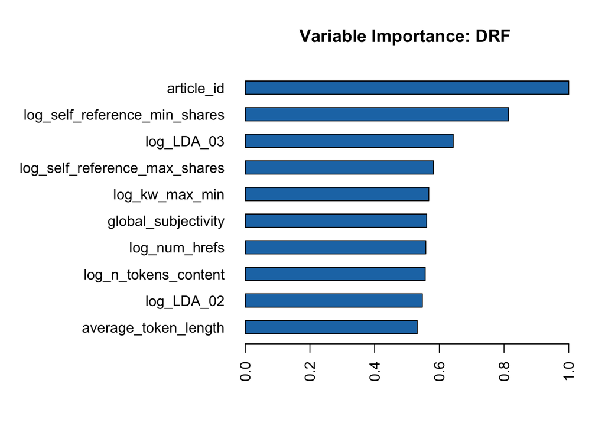

```r
# check variable importance
h2o.varimp_plot(best_rf)
```

```r
rf_varimp <- h2o.varimp(best_rf)
rf_varimp <- rf_varimp %>% filter(scaled_importance < 0.05)

x_log_rf <- setdiff(x_log2, c("data_channel_is_bus"))
```

#### d. Gradient boosting model

When I trained the gradient boosting model I followed the same process as for the random forest model. I used the grid search first and then ran a model separately with the best parameters. Then I saved the model, checked the AUC values and calculated the predcition.

```r
# GBM
# train model
# gbm_model <- h2o.gbm(
#   x = x_log2, y = y,
#   model_id = "gbm_model",
#   training_frame = data_train,
#   nfolds = 5,
#   seed = my_seed,
#   learn_rate = 0.05,
#   ntrees = 300,
#   max_depth = 3,
#   #sample_rate = c(0.2, 0.5, 0.8, 1),
#   validation_frame = data_valid,
#   keep_cross_validation_predictions = TRUE
# )

# save model to file
#model_path <- h2o.saveModel(object = gbm_model, path = "/Users/JAS/Documents/Kata/Kaggle competition/models/", force = TRUE)

# import model from file
best_gbm <- h2o.loadModel("/Users/JAS/Documents/Kata/Kaggle competition/models/gbm_model")

# get AUC for best gbm model
gbm_auc <- h2o.auc(best_gbm, train = TRUE, xval = TRUE, valid = TRUE)

# prediction for test set
#prediction <- h2o.predict(best_gbm, newdata = data_test)

# bind predictions with article id-s
#solution <- cbind(test[, 'article_id'], as.data.frame(prediction[, 3]))

# rename columns
#colnames(solution) <- c('article_id', 'score')

# write to csv
#write_csv(solution, '/Users/JAS/Documents/Kata/Kaggle competition/submissions/best_gbm.csv')
```

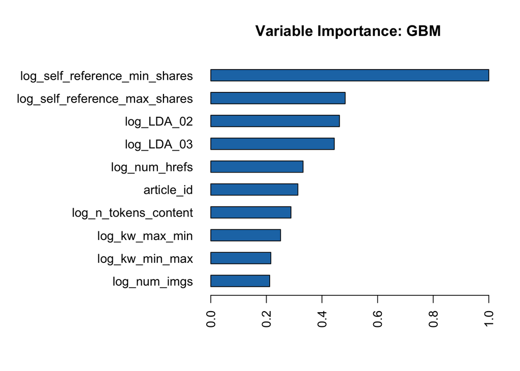

```r
# check variable importance
h2o.varimp_plot(best_gbm)
```

```r
gbm_varimp <- h2o.varimp(best_gbm)
gbm_varimp <- gbm_varimp %>% filter(scaled_importance < 0.01)

x_log_gbm <- setdiff(x_log2, c("weekday_is_monday", "weekday_is_friday", "weekday_is_thursday", "weekday_is_wednesday"))
```

#### e. XGBoost model

I experimented with different parameter settings for the xgboost model as well. I saved the best one, calculated the AUC values and then the predictions.

```r
# GBM
# train model
# xgboost_model <- h2o.xgboost(
#   x = x_log_xgboost, y = y,
#   model_id = "xgboost_model",
#   training_frame = data_train,
#   nfolds = 5,
#   seed = my_seed,
#   learn_rate = 0.07,
#   ntrees = 300,
#   max_depth = 2,
#   sample_rate = 0.5,
#   validation_frame = data_valid,
#   keep_cross_validation_predictions = TRUE
# )

# save model to file
#model_path <- h2o.saveModel(object = xgboost_model, path = "/Users/JAS/Documents/Kata/Kaggle competition/models/", force = TRUE)

# import model from file
best_xgboost <- h2o.loadModel("/Users/JAS/Documents/Kata/Kaggle competition/models/xgboost_model")

# get AUC for best gbm model
xgboost_auc <- h2o.auc(best_xgboost, train = TRUE, xval = TRUE, valid = TRUE)

# prediction for test set
#prediction <- h2o.predict(best_xgboost, newdata = data_test)

# bind predictions with article id-s
#solution <- cbind(test[, 'article_id'], as.data.frame(prediction[, 3]))

# rename columns
#colnames(solution) <- c('article_id', 'score')

# write to csv
#write_csv(solution, '/Users/JAS/Documents/Kata/Kaggle competition/submissions/best_xgboost.csv')
```

Then just like before I checked the variable importance and filtered the features with an importance lower than 0.01 and checked whether it improved performance.

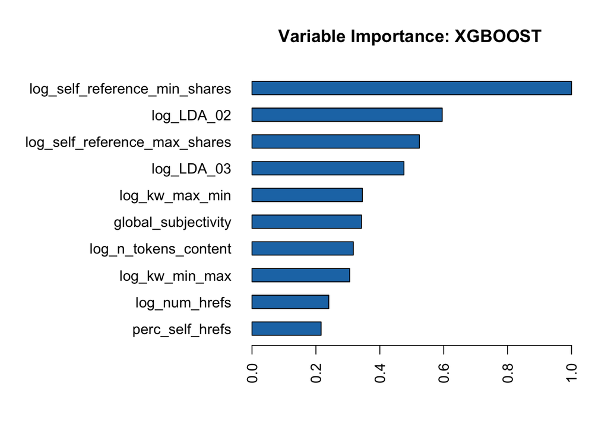

```r
# check variable importance
h2o.varimp_plot(best_xgboost)
```

```r
xgboost_varimp <- h2o.varimp(best_xgboost)
xgboost_varimp <- xgboost_varimp %>% filter(scaled_importance < 0.01)

x_log_xgboost <- setdiff(x_log2, c("kw_max_max", "data_channel_is_world", "weekday_is_friday", "weekday_is_thursday"))
```

In general, for the tree-based models it was important not to train too many trees because that led to overfitting.

#### f. Neural network model

As for the neural network model I experimented with different parameter settings. The final model had two hidden layers and used dropout rates of 0.6 and 0.5. I saved the best model, checked the AUC values and calculated predictions.

```r
### NEURAL NETWORK MODEL

# train model
# nn_model <- h2o.deeplearning(
#   x_log2, y,
#   training_frame = data_train,
#   model_id = "nn_model",
#   standardize = TRUE,
#   hidden = c(50, 20),
#   seed = my_seed,
#   nfolds = 5,
#   validation_frame = data_valid,
#   activation = "RectifierWithDropout",
#   epochs = 30,
#   mini_batch_size = 10,
#   hidden_dropout_ratios = c(0.6, 0.5),
#   keep_cross_validation_predictions = TRUE
# )

# save model to file
#model_path <- h2o.saveModel(object = nn_model, path = "/Users/JAS/Documents/Kata/Kaggle competition/models/", force = TRUE)

# import model from file
best_nn <- h2o.loadModel("/Users/JAS/Documents/Kata/Kaggle competition/models/nn_model")

# get AUC for best neural network model
nn_auc <- h2o.auc(best_nn, train = TRUE, xval = TRUE, valid = TRUE)

# prediction for test set
#prediction <- h2o.predict(best_nn, newdata = data_test)

# bind predictions with article id-s
#solution <- cbind(test[, 'article_id'], as.data.frame(prediction[, 3]))

# rename columns
#colnames(solution) <- c('article_id', 'score')

# write to csv
#write_csv(solution, '/Users/JAS/Documents/Kata/Kaggle competition/submissions/best_nn.csv')
```

#### g. Stacked model

Lastly, I built a stacked ensemble model in which I combined all the previously built models and used glm as the meta learner. The way the stacked model works is that it fits a model on the predictions of other models to improve predictive performance. It works best when the base learner models are not highly correlated.

Just like before I saved the model, checked the AUC values and calculated predictions.

```r
### STACKED MODEL

# save models to a list
base_learners <- list(
  best_lasso, best_rf, best_gbm, best_xgboost, best_nn
)

# stacked ensemble model with glm as the meta learner
# ensemble_model <- h2o.stackedEnsemble(
#   x_log2, y,
#   model_id = "stacked_model",
#   training_frame = data_train,
#   base_models = base_learners,
#   validation_frame = data_valid,
#   seed = my_seed,
#   metalearner_nfolds = 5
# )

# save model to file
#model_path <- h2o.saveModel(object = ensemble_model, path = "/Users/JAS/Documents/Kata/Kaggle competition/models/", force = TRUE)

# import model from file
best_stacked <- h2o.loadModel("/Users/JAS/Documents/Kata/Kaggle competition/models/StackedEnsemble_model_R_1616151557052_270669")

# get AUC for best stacked model
stacked_auc <- h2o.auc(best_stacked, train = TRUE, xval = TRUE, valid = TRUE)

# prediction for test set
#prediction <- h2o.predict(best_stacked, newdata = data_test)

# bind predictions with article id-s
#solution <- cbind(test[, 'article_id'], as.data.frame(prediction[, 3]))

# rename columns
#colnames(solution) <- c('article_id', 'score')

# write to csv
#write_csv(solution, '/Users/JAS/Documents/Kata/Kaggle competition/submissions/best_stacked.csv')
```

## 5. Model comparison

Below is a comparison table of the performances of all the models. We can see that the model with the best performance is the stacked model. It has the highest cross-validated and validation AUC.

```r
### MODEL COMPARISON
# save models to a list
my_models <- list(
  best_lasso, best_rf, best_gbm, best_xgboost, best_nn, best_stacked
)

# create table with AUC values for different models
auc_on_valid <- map_df(my_models, ~{
  tibble(model = .@model_id, RMSE = h2o.rmse(., xval = TRUE), AUC_xval = h2o.auc(., xval = TRUE), AUC_valid = h2o.auc(h2o.performance(., data_valid)))
}) %>% arrange(AUC_valid)

names(auc_on_valid) <- c("Model", "Cross-validated RMSE","Cross-validated AUC", "Validation AUC")

auc_on_valid <- auc_on_valid %>% mutate( Model = ifelse(Model == "StackedEnsemble_model_R_1616151557052_270669", "stacked_model", Model))

# print table
knitr::kable( auc_on_valid, caption = "Performance comparison of all models", digits = 3 ) %>% kable_styling( position = "center", latex_options = 'hold_position', bootstrap_options = c("striped", "hover"))
```

Performance comparison of all models

| Model | Cross-validated RMSE | Cross-validated AUC | Validation AUC |
| --- | --- | --- | --- |
| lasso_model | 0.388 | 0.669 | 0.670 |
| nn_model | 0.390 | 0.669 | 0.680 |
| rf_model | 0.384 | 0.689 | 0.685 |
| gbm_model | 0.382 | 0.702 | 0.691 |
| xgboost_model | 0.382 | 0.702 | 0.691 |
| stacked_model | 0.382 | 0.704 | 0.701 |

Below I plotted the ROC curve for the best performing model which was the stacked model. We can conclude that there is room for improvement since the curve is relatively close to the 45 degree line.

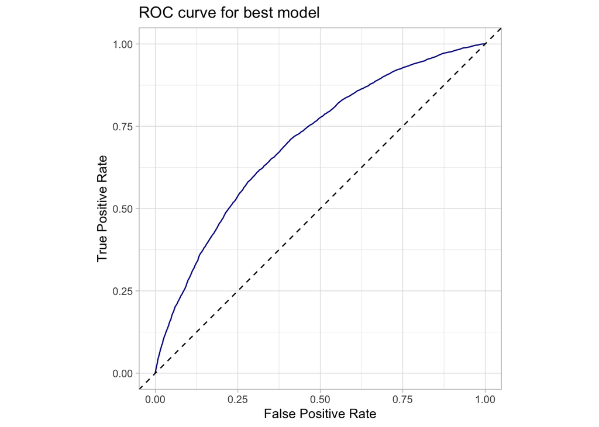

```r
# plot ROC curve for best model
# function to get performance metrics for the plot
getPerformanceMetrics <- function(model, newdata = NULL, xval = FALSE) {
  h2o.performance(model, newdata = newdata, xval = xval)@metrics$thresholds_and_metric_scores %>%
    as_tibble() %>%
    mutate(model = model@model_id)
}

# calculate performance metrics
best_performance <- getPerformanceMetrics(best_stacked, xval = TRUE)

# create plot
ggplot(best_performance, aes(fpr, tpr)) +
    geom_path(color = "darkblue") +
    geom_abline(slope = 1, intercept = 0, linetype = "dashed") +
    coord_fixed() +
    labs(x = "False Positive Rate", y = "True Positive Rate", title = "ROC curve for best model")
```